# Moderation in the APIM

# Load the Data

Read in the pairwise dataset and load the packages

```r
library(dyadr)
library(dplyr)
library(nlme)
library(ggplot2)

riggsp <- read.csv(file.choose(), header=TRUE)
```

# Riggs Example

**Outcome:** [Sat_A] Satisfaction  
**Predictor Variables:** [Avoid_A, Avoid_P] Adult avoidant attachment (Actor and Partner), a mixed variable.  
**Moderators:** [Anxiety_A, Anxiety_P] Adult anxious attachment (Actor and Partner), a mixed variable.

## Data Preparation

We first grand-mean center the moderator and predictor variables.

```r
riggsp <- riggsp %>%
  mutate(CAvoid_A = Avoid_A - mean(Avoid_A),
         CAvoid_P = Avoid_P - mean(Avoid_P),
         CAnxiety_A = Anxiety_A - mean(Anxiety_A),
         CAnxiety_P = Anxiety_P - mean(Anxiety_P))
```

## Saturated Two-Intercept Model

We then estimate the two-intercept model with the string gender variable and all of the anxiety by avoidance interactions:

```r
apim_sat_two <- gls(Sat_A ~ Genderstring + CAvoid_A:Genderstring
                    + CAvoid_P:Genderstring + CAnxiety_A:Genderstring
                    + CAnxiety_P:Genderstring
                    + CAnxiety_A:CAvoid_A:Genderstring
                    + CAnxiety_A:CAvoid_P:Genderstring
                    + CAnxiety_P:CAvoid_A:Genderstring
                    + CAnxiety_P:CAvoid_P:Genderstring - 1,
                    data = riggsp,
                    correlation = corCompSymm(form=~1|Dyad),
                    weights = varIdent(form=~1|Genderstring),
                    na.action = na.omit)

smallsummary(apim_sat_two)
```

```
## Correlation structure of class corCompSymm representing
##       Rho
## 0.6222822
## Variance function structure of class varIdent representing
##      Man    Woman
## 1.000000 1.077605
##                                             Value Std.Error     t-value
## GenderstringMan                       45.36417004 0.5766886 78.66320014
## GenderstringWoman                     45.46807296 0.6214423 73.16539954
## GenderstringMan:CAvoid_A              -1.28498893 0.5030984 -2.55415022
## GenderstringWoman:CAvoid_A            -1.32073597 0.5667589 -2.33033123
## GenderstringMan:CAvoid_P               0.02089885 0.5259433  0.03973593
## GenderstringWoman:CAvoid_P            -0.40607032 0.5421412 -0.74901214
## GenderstringMan:CAnxiety_A            -1.22839846 0.4338011 -2.83170915
## GenderstringWoman:CAnxiety_A          -1.62075391 0.4903655 -3.30519558
## GenderstringMan:CAnxiety_P            -1.10139566 0.4550514 -2.42037628
## GenderstringWoman:CAnxiety_P          -0.91231045 0.4674660 -1.95160800
## GenderstringMan:CAvoid_A:CAnxiety_A    1.42497632 0.3989027  3.57224043
## GenderstringWoman:CAvoid_A:CAnxiety_A -0.98335163 0.4808613 -2.04497966
## GenderstringMan:CAvoid_P:CAnxiety_A   -1.14885037 0.4214101 -2.72620543
## GenderstringWoman:CAvoid_P:CAnxiety_A -0.31601777 0.4496364 -0.70282966
## GenderstringMan:CAvoid_A:CAnxiety_P   -0.02430499 0.4172554 -0.05824966
## GenderstringWoman:CAvoid_A:CAnxiety_P -0.28391464 0.4541134 -0.62520646
## GenderstringMan:CAvoid_P:CAnxiety_P   -0.96127613 0.4462317 -2.15420856
## GenderstringWoman:CAvoid_P:CAnxiety_P  0.38079099 0.4298594  0.88585014
##                                             p-value
## GenderstringMan                       1.366951e-198
## GenderstringWoman                     7.608797e-190
## GenderstringMan:CAvoid_A               1.115247e-02
## GenderstringWoman:CAvoid_A             2.046985e-02
## GenderstringMan:CAvoid_P               9.683308e-01
## GenderstringWoman:CAvoid_P             4.544528e-01
## GenderstringMan:CAnxiety_A             4.951822e-03
## GenderstringWoman:CAnxiety_A           1.067521e-03
## GenderstringMan:CAnxiety_P             1.611462e-02
## GenderstringWoman:CAnxiety_P           5.194062e-02
## GenderstringMan:CAvoid_A:CAnxiety_A    4.138415e-04
## GenderstringWoman:CAvoid_A:CAnxiety_A  4.175315e-02
## GenderstringMan:CAvoid_P:CAnxiety_A    6.793933e-03
## GenderstringWoman:CAvoid_P:CAnxiety_A  4.827219e-01
## GenderstringMan:CAvoid_A:CAnxiety_P    9.535896e-01
## GenderstringWoman:CAvoid_A:CAnxiety_P  5.323238e-01
## GenderstringMan:CAvoid_P:CAnxiety_P    3.204181e-02
## GenderstringWoman:CAvoid_P:CAnxiety_P  3.764272e-01
```

```
##                                            2.5 %      97.5 %
## GenderstringMan                       44.2338812 46.49445891
## GenderstringWoman                     44.2500685 46.68607746
## GenderstringMan:CAvoid_A              -2.2710437 -0.29893415
## GenderstringWoman:CAvoid_A            -2.4315630 -0.20990893
## GenderstringMan:CAvoid_P              -1.0099310  1.05172874
## GenderstringWoman:CAvoid_P            -1.4686475  0.65650685
## GenderstringMan:CAnxiety_A            -2.0786329 -0.37816399
## GenderstringWoman:CAnxiety_A          -2.5818526 -0.65965517
## GenderstringMan:CAnxiety_P            -1.9932801 -0.20951127
## GenderstringWoman:CAnxiety_P          -1.8285270  0.00390614
## GenderstringMan:CAvoid_A:CAnxiety_A    0.6431414  2.20681123
## GenderstringWoman:CAvoid_A:CAnxiety_A -1.9258225 -0.04088075
## GenderstringMan:CAvoid_P:CAnxiety_A   -1.9747989 -0.32290185
## GenderstringWoman:CAvoid_P:CAnxiety_A -1.1972888  0.56525330
## GenderstringMan:CAvoid_A:CAnxiety_P   -0.8421106  0.79350060
## GenderstringWoman:CAvoid_A:CAnxiety_P -1.1739606  0.60613129
## GenderstringMan:CAvoid_P:CAnxiety_P   -1.8358742 -0.08667808
## GenderstringWoman:CAvoid_P:CAnxiety_P -0.4617179  1.22329989
```

We see that 4 of the 8 moderation effects are statistically significant. Six of the eight coefficients are negative. Note that all significant actor and partner effects for anxiety and avoidance are negative—so in general, a negative interaction effect indicates a more-is-worse effect whereas a positive interaction effect indicates an alleviation effect.

### Interpretation

**Avoid_A with Anxiety_P (Man)**: (not significant) We would predict the negative effect of men’s own avoidance on their satisfaction to be stronger as the woman’s anxiety goes up.

**Avoid_A with Anxiety_P (Woman)**: (not significant) We would predict the negative effect of women’s own avoidance on their satisfaction to be stronger as the man’s anxiety goes up.

## Testing for Gender Differences in Moderation Effects

We can test if these interaction are significantly different across gender by using the test function.

```r
gen_tests <- data.frame(act_act = lincomb(summary(apim_sat_two), 11, 12),
                        prt_act = lincomb(summary(apim_sat_two), 13, 14),
                        act_prt = lincomb(summary(apim_sat_two), 15, 16),
                        prt_prt = lincomb(summary(apim_sat_two), 17, 18),
                        row.names = c("Mean diff", "SE", "p-value"))

gen_tests
```

```
##                act_act    prt_act   act_prt     prt_prt
## Mean diff 2.4083279513 -0.8328326 0.2596097 -1.34206712
## SE        0.6498318363  0.6453611 0.6457962  0.64485056
## p-value   0.0002104929  0.1968803 0.6876845  0.03741502
```

### Gender Interaction Approach

Alternatively, we can test if these moderation effects are significantly different across gender by running the model with gender interactions.

```r
apim_sat_int <- gls(Sat_A ~ CAnxiety_A*CAvoid_A*Gender_A
                    + CAnxiety_A*CAvoid_P*Gender_A
                    + CAnxiety_P*CAvoid_A*Gender_A
                    + CAnxiety_P*CAvoid_P*Gender_A,
                    data = riggsp,
                    correlation = corCompSymm(form=~1|Dyad),
                    weights = varIdent(form=~1|Gender_A),
                    na.action = na.omit)

coef(summary(apim_sat_int))
```

```
##                                    Value Std.Error     t-value
## (Intercept)                  45.41612150 0.5396262 84.16219461
## CAnxiety_A                   -1.42457619 0.3208972 -4.43935351
## CAvoid_A                     -1.30286245 0.3739701 -3.48386766
## Gender_A                      0.05195146 0.2611202  0.19895615
## CAvoid_P                     -0.19258574 0.3727011 -0.51672976
## CAnxiety_P                   -1.00685306 0.3197087 -3.14928235
## CAnxiety_A:CAvoid_A           0.22081234 0.2993412  0.73766113
## CAnxiety_A:Gender_A          -0.19617772 0.3336852 -0.58791253
## CAvoid_A:Gender_A            -0.01787352 0.3838075 -0.04656897
## CAnxiety_A:CAvoid_P          -0.73243407 0.2928428 -2.50111695
## Gender_A:CAvoid_P            -0.21348458 0.3825710 -0.55802598
## CAvoid_A:CAnxiety_P          -0.15410981 0.2930825 -0.52582402
## Gender_A:CAnxiety_P           0.09454260 0.3325424  0.28430237
## CAvoid_P:CAnxiety_P          -0.29024257 0.2966359 -0.97844730
## CAnxiety_A:CAvoid_A:Gender_A -1.20416398 0.3249159 -3.70607874
## CAnxiety_A:Gender_A:CAvoid_P  0.41641630 0.3226806  1.29049081
## CAvoid_A:Gender_A:CAnxiety_P -0.12980483 0.3228981 -0.40199934
## Gender_A:CAvoid_P:CAnxiety_P  0.67103356 0.3224253  2.08120639
##                                    p-value
## (Intercept)                  8.469629e-207
## CAnxiety_A                    1.280854e-05
## CAvoid_A                      5.699687e-04
## Gender_A                      8.424355e-01
## CAvoid_P                      6.057360e-01
## CAnxiety_P                    1.806324e-03
## CAnxiety_A:CAvoid_A           4.613128e-01
## CAnxiety_A:Gender_A           5.570454e-01
## CAvoid_A:Gender_A             9.628886e-01
## CAnxiety_A:CAvoid_P           1.292790e-02
## Gender_A:CAvoid_P             5.772542e-01
## CAvoid_A:CAnxiety_P           5.994096e-01
## Gender_A:CAnxiety_P           7.763802e-01
## CAvoid_P:CAnxiety_P           3.286631e-01
## CAnxiety_A:CAvoid_A:Gender_A  2.517722e-04
## CAnxiety_A:Gender_A:CAvoid_P  1.979012e-01
## CAvoid_A:Gender_A:CAnxiety_P  6.879786e-01
## Gender_A:CAvoid_P:CAnxiety_P  3.828620e-02
```

Looking at these three-way interactions with gender we find significant gender differences in the actor-actor moderation effect and the partner-partner moderation effect:

```r
coef(summary(apim_sat_int))[15:18,]
```

```
##                                   Value Std.Error    t-value      p-value
## CAnxiety_A:CAvoid_A:Gender_A -1.2041640 0.3249159 -3.7060787 0.0002517722
## CAnxiety_A:Gender_A:CAvoid_P  0.4164163 0.3226806  1.2904908 0.1979012063
## CAvoid_A:Gender_A:CAnxiety_P -0.1298048 0.3228981 -0.4019993 0.6879786018
## Gender_A:CAvoid_P:CAnxiety_P  0.6710336 0.3224253  2.0812064 0.0382861982
```

These are the same p-values we found with `lincomb()`.

```r
cbind(t(gen_tests[3,]), coef(summary(apim_sat_int))[15:18,4])
```

```
##              p-value
## act_act 0.0002104929 0.0002517722
## prt_act 0.1968802989 0.1979012063
## act_prt 0.6876845149 0.6879786018
## prt_prt 0.0374150187 0.0382861982
```

You could also perform an omnibus test to see if there is distinguishability in the moderation effects.

```r
apim_sat_int <- gls(Sat_A ~ CAnxiety_A*CAvoid_A*Gender_A
                        + CAnxiety_A*CAvoid_P*Gender_A
                        + CAnxiety_P*CAvoid_A*Gender_A
                        + CAnxiety_P*CAvoid_P*Gender_A,
                    method = "ML", #using ML
                    data = riggsp,
                    correlation = corCompSymm(form=~1|Dyad),
                    weights = varIdent(form=~1|Gender_A),
                    na.action = na.omit)


apim_sat_noMod <- gls(Sat_A ~ CAnxiety_A*CAvoid_A*Gender_A
                          + CAnxiety_A*CAvoid_P*Gender_A
                          + CAnxiety_P*CAvoid_A*Gender_A
                          + CAnxiety_P*CAvoid_P*Gender_A
                      - CAnxiety_A:CAvoid_A:Gender_A
                      - CAnxiety_A:CAvoid_P:Gender_A
                      - CAnxiety_P:CAvoid_A:Gender_A
                      - CAnxiety_P:CAvoid_P:Gender_A,
                    method = "ML", #using ML
                    data = riggsp,
                    correlation = corCompSymm(form=~1|Dyad),
                    weights = varIdent(form=~1|Gender_A),
                    na.action = na.omit)

anova(apim_sat_int, apim_sat_noMod)
```

```
##                Model df      AIC      BIC    logLik   Test  L.Ratio
## apim_sat_int       1 21 1975.818 2054.286 -966.9091
## apim_sat_noMod     2 17 1984.438 2047.960 -975.2192 1 vs 2 16.62009
##                p-value
## apim_sat_int
## apim_sat_noMod  0.0023
```

There is distinguishability in the moderation effects $\chi^2(4) = 16.62$, $p = .002$. Also, when we test for complete indistinguishability, we find $\chi^2(10) = 19.05$, $p = .040$, they are distinguishable.

```r
apim_sat_indist <- gls(Sat_A ~ CAnxiety_A*CAvoid_A + CAnxiety_A*CAvoid_P
                       + CAnxiety_P*CAvoid_A + CAnxiety_P*CAvoid_P,
                    data = riggsp,
                    method = "ML", #using ML
                    correlation = corCompSymm(form=~1|Dyad),
                    na.action = na.omit)

anova(apim_sat_int, apim_sat_indist)
```

```
##                 Model df      AIC      BIC    logLik   Test  L.Ratio
## apim_sat_int        1 21 1975.818 2054.286 -966.9091
## apim_sat_indist     2 11 1974.871 2015.973 -976.4353 1 vs 2 19.05231
##                 p-value
## apim_sat_int
## apim_sat_indist  0.0396
```

However, to simplify things **for illustration purposes only**, we estimate a model of complete indistinguishability, i.e., no gender effects.

```r
coef(summary(apim_sat_indist))
```

```
##                          Value Std.Error    t-value       p-value
## (Intercept)         45.0694296 0.5322459 84.6778386 5.610228e-212
## CAnxiety_A          -1.5185217 0.3188420 -4.7626149  2.975291e-06
## CAvoid_A            -1.6438054 0.3668660 -4.4806692  1.058333e-05
## CAvoid_P            -0.3284803 0.3668660 -0.8953686  3.713055e-01
## CAnxiety_P          -0.9760280 0.3188420 -3.0611649  2.403620e-03
## CAnxiety_A:CAvoid_A  0.2801181 0.2868884  0.9764008  3.296499e-01
## CAnxiety_A:CAvoid_P -0.7113750 0.2957550 -2.4052850  1.676315e-02
## CAvoid_A:CAnxiety_P -0.0850710 0.2957550 -0.2876401  7.738202e-01
## CAvoid_P:CAnxiety_P -0.2198018 0.2868884 -0.7661578  4.441828e-01
```

There is only one statistically significant interaction, the actor anxiety by partner avoidance effect. We can interpret this as, at a mean level of actor anxiety there we would expect no effect of one’s partner’s avoidance (it is non-sig), but as one’ anxiety goes up, partner’s avoidance has a negative effect on satisfaction.

## Testing Simple Slopes

To interpret the interaction and test for simple slopes (at 1 SD above and below the mean for anxiety), we can use the method of re-centering. To estimate the simple slopes of partner avoidance at high and low actor anxiety, for example, we re-estimate the model for those who are 1 standard deviation (sd) above and then 1 sd below the mean on actor anxiety. We then look at the “main effect” of partner avoidance as it will now refer to effect of `CAvoid_P` when `CAnxiety_A` is one standard deviation above the mean (high) or one standard deviation below the mean (low).

Note that to have CAnxiety_A be zero when it is one sd above the mean, we subtract 1 sd from the centered score and add 1 sd for one sd below the mean:

```r
riggsp <- riggsp %>%
  mutate(High_CAnxiety_A = CAnxiety_A - sd(CAnxiety_A),
         Low_CAnxiety_A = CAnxiety_A + sd(CAnxiety_A))
```

This might feel counterintuitive, but you can convince yourself! We then re-run the model 2 times using these 2 re-centered variables:

```r
apim_axa_high <- gls(Sat_A ~ High_CAnxiety_A*CAvoid_A
                     + High_CAnxiety_A*CAvoid_P
                     + CAnxiety_P*CAvoid_A
                     + CAnxiety_P*CAvoid_P,
                    data = riggsp,
                    correlation = corCompSymm(form=~1|Dyad),
                    na.action = na.omit)

coef(summary(apim_axa_high))
```

```
##                               Value Std.Error    t-value       p-value
## (Intercept)              43.1814265 0.6302782 68.5116905 1.181155e-185
## High_CAnxiety_A          -1.5185217 0.3191612 -4.7578519  3.041299e-06
## CAvoid_A                 -1.2955299 0.5226936 -2.4785647  1.373915e-02
## CAvoid_P                 -1.2129447 0.5034623 -2.4092067  1.658755e-02
## CAnxiety_P               -0.9760280 0.3191612 -3.0581036  2.427554e-03
## High_CAnxiety_A:CAvoid_A  0.2801181 0.2871508  0.9755088  3.300913e-01
## High_CAnxiety_A:CAvoid_P -0.7113750 0.2960143 -2.4031780  1.685818e-02
## CAvoid_A:CAnxiety_P      -0.0850710 0.2960143 -0.2873882  7.740129e-01
## CAvoid_P:CAnxiety_P      -0.2198018 0.2871508 -0.7654579  4.445987e-01
```

When actor anxiety is high there is a significant negative effect of the partner’s avoidance on satisfaction.

```r
apim_axa_Low <- gls(Sat_A ~ Low_CAnxiety_A*CAvoid_A
                    + Low_CAnxiety_A*CAvoid_P
                    + CAnxiety_P*CAvoid_A
                    + CAnxiety_P*CAvoid_P,
                    data = riggsp,
                    correlation = corCompSymm(form=~1|Dyad),
                    na.action = na.omit)

coef(summary(apim_axa_Low))
```

```
##                              Value Std.Error    t-value       p-value
## (Intercept)             46.9574327 0.6972366 67.3479140 1.496934e-183
## Low_CAnxiety_A          -1.5185217 0.3191612 -4.7578519  3.041299e-06
## CAvoid_A                -1.9920808 0.5014496 -3.9726444  8.900647e-05
## CAvoid_P                 0.5559840 0.5358792  1.0375174  3.003275e-01
## CAnxiety_P              -0.9760280 0.3191612 -3.0581036  2.427554e-03
## Low_CAnxiety_A:CAvoid_A  0.2801181 0.2871508  0.9755088  3.300913e-01
## Low_CAnxiety_A:CAvoid_P -0.7113750 0.2960143 -2.4031780  1.685818e-02
## CAvoid_A:CAnxiety_P     -0.0850710 0.2960143 -0.2873882  7.740129e-01
## CAvoid_P:CAnxiety_P     -0.2198018 0.2871508 -0.7654579  4.445987e-01
```

Now we see that when actor anxiety is low there is no statistically significant negative effect of partner avoidance, in fact, the coefficient for partner avoidance is now positive. on satisfaction. But this coefficient is not significantly different from zero.

## Making Interaction Figures

It would be nice to have a figure for the moderation of partner avoidance effect by actor anxiety.

To graph this interaction we need to note the position of the y-intercept and slope for CAvoid_P when CAnxiety_A is high and the y-intercept and slope for CAvoid_P when CAnxiety_A low. In this case the positions are 1 and 4 respectively. Then, we can use the `graphMod()` function in `dyadr` to make the figure. Recall that you can run the command `?graphMod` to see what the `graphMod()` function needs.

```r
?graphMod
```

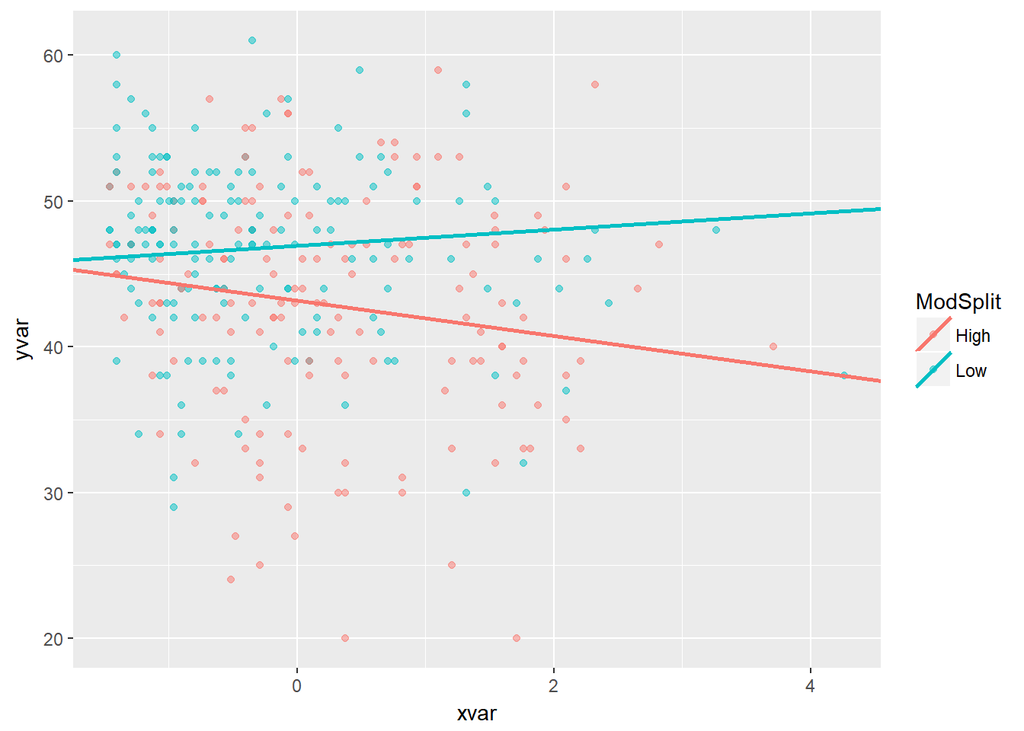

```r
plot <- graphMod(riggsp,
                 riggsp$CAvoid_P,
                 riggsp$Sat_A,
                 riggsp$CAnxiety_A,
                 apim_axa_high,
                 apim_axa_Low,
                 1, 4)

plot
```

We can then add labels and change the colors, etc.

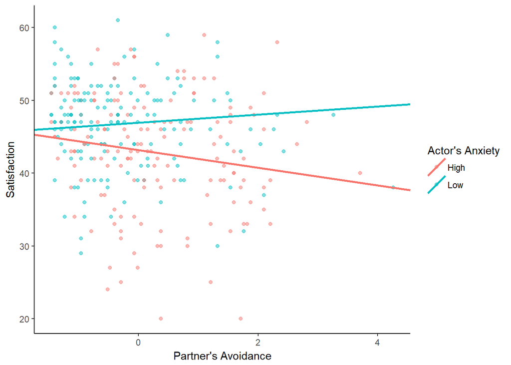

```r
plot +
  theme_classic() +
  ylab("Satisfaction") +
  xlab("Partner's Avoidance") +
  scale_color_manual(values = c("cadetblue", "salmon")) +
  scale_color_discrete(name = "Actor's Anxiety")
```